# DATA621 Final Project

IvanTikhonov, Seung Min Song, Alice Firedman

## Abstract

This study investigates the external factors affecting students’ academic performance in secondary schools’ math and Portuguese language courses. Using a quantitative dataset obtained through a survey, the study analyzes various external variables, such as students’ health, social and demographic factors, study habits, and other relevant factors to understand their impact on academic performance.

This study’s methodology and results will be of interest to researchers in the field of education, providing a basis for future studies on external factors that impact academic performance. Overall, the study’s findings have significant implications for the education sector, providing insights that can inform future efforts to support student academic success and improve educational outcomes. The study’s methodology and results are of interest to educators, policymakers, and other stakeholders in the education sector and can contribute to the development of evidence-based practices.

## Introduction

This study may be relevant to you as it explores the external factors that have an impact on students’ grades. By analyzing the various external variables that can influence academic performance, this study provides valuable insights that can help parents, educators, and policymakers to better support students’ success in school. Specifically, this study looks at factors such as students’ health, social and demographic factors, study habits, and other relevant factors that can have an impact on their academic performance.

Understanding the external factors that can affect a student’s academic performance can be helpful in creating a supportive home environment and developing effective strategies to help a child succeed in school. This study’s findings could also be useful for parents and educators to monitor and provide proper guidelines for external factors that may affect students’ academic performance, such as romantic relationships, drinking habits, and how they use their free time. By gaining a deeper understanding of how these factors impact students’ grades, parents and educators can work to create a more supportive environment for students and help them develop healthy habits that promote academic success.

In the wider educational industry, the findings of this study can provide insights into how to better support students’ academic success and enhance their overall educational experience. Educators and policymakers can use this research to identify areas where they can improve educational outcomes, such as implementing programs to support students’ health or providing resources to help students develop effective study habits.

## Key Words

- external factors
- internal factors
- academic performance
- Weighted Least Square Regression
- multiple linear regression
- health
- internet access
- study habits
- educational outcomes

## Literature Review

A large number of factors have been identified in previous studies to predict academic achievement including sex, screen time, sleep, cell-phone use, maternal education, IQ; however, the effect typically found is low (explaining between approximately 6% and 50% of variation). This indicates that other factors not included in the study (which may include student-specifc habits like study habits or school-related factors like school quality) may impact variation, and that the true model is likely complex.

### [Title: Application of Multiple Linear Regression Identifying Contributing Factors in Students’Academic Achievement]((https://www.researchgate.net/publication/366929441_Application_of_Multiple_Linear_Regression_in_Identifying_Contributing_Factors_in_Students%27_Academic_Achievement)

Authors: Dg Siti Nurisya Sahirah Binti Ag Isha and Siti Rahayu Binti Mohd Hashim Proceedings of the International Conference on Mathematical Sciences and Statistics 2022 (ICMSS 2022)At: Selangor, Malaysia Mathematics With Economics Programme, Faculty of Science and Natural Resources, December 2022

This study aimed to identify significant factors that contribute to students’ academic success by analyzing internal and external factors. The study involved 327 final-year undergraduate students and found that self-esteem, intelligence, and maternal education were significant factors affecting students’ achievement.

In this research, they made three different models to see which factors were most important for academic achievement. They found that self-esteem, IQ, and maternal education were the most important factors.

### [Title: A Study on Academic Achievement and Personality of Secondary School Students](https://files.eric.ed.gov/fulltext/EJ1149330.pdf)

Authors: Dr. Suvarna V. D.and Dr H. S. Ganesha Bhata1 Research in Pedagogy, v6 n1 p99-108, 2016

This study uses ANOVA and the Pearson’s product-moment coefficient to test hypotheses related to differences in academic achievement between different groups of students (including both demographics and responses to a personality test ) using a dataset of approximately 300 secondary school students.The results find that the students’ age and gender affect their achievement levels, but that other demographic categories and (interestingly) personality characteristics do not.

### [Predictors of Academic Performance in High School Students: The Longitudinal ASAP Study](https://www.ncbi.nlm.nih.gov/pmc/articles/PMC9365103/#:~:text=Finally%2C%20psychological%20factors%20such%20as,42%2C%2043%2C%2048).)

Authors: Marie-Maude Dubuc, Mylene Aubertin-Leheudr, and Antony D. Karelis Published online 2022 May 1, International Journal of Exercise

This study used moderated multivariate linear regression, separately comparing male and female students, to evaluate the impact of social, physical, and cogntive factors to explain variation in academic achievement among a cohort of 185 high-school students evaluated at a single high school over three years. The researchers controlled for demographic factors such as race, income, and ethnicity and use both a cross-sectional and longitudinal approach. In their results, they found that sex, cardiovascular fitness (measured by VO2 Max), and workign memory were important predictors; however, they found that results differed when controlling for sex, school subject, and study design indicating that academic performance is in fact a highly complex phenomenon.

## Data Source

We will use the data set to predict academic achievement represented by the final grades, `G3`. A data dictionary is included in Appendix 1.

## Data Exploration

Include:

- Summary statistics means, medians, quartiles,
- Missing value information
- EDA
  - The dataframe df_mat contains 395 entries (rows) with 33 columns.
  - The dataset df_por contains 649 entries (rows) with 33 columns.
  - The data types of the columns include integers (int64) and objects (object).
  - The columns represent various features of the student dataset such as personal and family characteristics, academic performance, and social activities.
  - Some of the columns include: **school**, **sex**, **age**, **address**, **family size**, **parents’ education**, **mother and father’s occupation**, **travel time**, **study time**, **number of failures**, **support received from school**, **family**, **extra-curricular**, **activities**, **health**, and **academic grades**.

### Overall Statistics

To gain comprehensive insights, we can merge *df_mat* and *df_por* datasets and analyze their collective statistics. There are 1044 observations (or cases) and 33 variables (or columns) in the df_student dataset.

When examining the distinctive variables in the **df_student**, a few noteworthy ones stand out:

```
##             vars    n  mean   sd median trimmed  mad min max range  skew
## school*        1 1044  1.26 0.44      1    1.20 0.00   1   2     1  1.09
## sex*           2 1044  1.43 0.50      1    1.42 0.00   1   2     1  0.27
## age            3 1044 16.73 1.24     17   16.67 1.48  15  22     7  0.43
## address*       4 1044  1.73 0.45      2    1.78 0.00   1   2     1 -1.02
## famsize*       5 1044  1.29 0.46      1    1.24 0.00   1   2     1  0.91
## Pstatus*       6 1044  1.88 0.32      2    1.98 0.00   1   2     1 -2.40
## Medu           7 1044  2.60 1.12      3    2.64 1.48   0   4     4 -0.14
## Fedu           8 1044  2.39 1.10      2    2.37 1.48   0   4     4  0.12
## Mjob*          9 1044  3.03 1.24      3    3.03 1.48   1   5     4 -0.24
## Fjob*         10 1044  3.25 0.86      3    3.30 0.00   1   5     4 -0.47
## reason*       11 1044  2.17 1.20      2    2.08 1.48   1   4     3  0.50
## guardian*     12 1044  1.84 0.53      2    1.83 0.00   1   3     2 -0.16
## traveltime    13 1044  1.52 0.73      1    1.38 0.00   1   4     3  1.37
## studytime     14 1044  1.97 0.83      2    1.89 1.48   1   4     3  0.67
## failures      15 1044  0.26 0.66      0    0.09 0.00   0   3     3  2.78
## schoolsup*    16 1044  1.11 0.32      1    1.02 0.00   1   2     1  2.43
## famsup*       17 1044  1.61 0.49      2    1.64 0.00   1   2     1 -0.46
## paid*         18 1044  1.21 0.41      1    1.14 0.00   1   2     1  1.42
## activities*   19 1044  1.49 0.50      1    1.49 0.00   1   2     1  0.02
## nursery*      20 1044  1.80 0.40      2    1.87 0.00   1   2     1 -1.50
## higher*       21 1044  1.91 0.28      2    2.00 0.00   1   2     1 -2.97
## internet*     22 1044  1.79 0.41      2    1.86 0.00   1   2     1 -1.44
## romantic*     23 1044  1.36 0.48      1    1.32 0.00   1   2     1  0.60
## famrel        24 1044  3.94 0.93      4    4.05 1.48   1   5     4 -1.05
## freetime      25 1044  3.20 1.03      3    3.20 1.48   1   5     4 -0.18
## goout         26 1044  3.16 1.15      3    3.16 1.48   1   5     4  0.04
## Dalc          27 1044  1.49 0.91      1    1.28 0.00   1   5     4  2.15
## Walc          28 1044  2.28 1.29      2    2.14 1.48   1   5     4  0.62
## health        29 1044  3.54 1.42      4    3.68 1.48   1   5     4 -0.50
## absences      30 1044  4.43 6.21      2    3.27 2.97   0  75    75  3.73
## G1            31 1044 11.21 2.98     11   11.18 2.97   0  19    19  0.08
## G2            32 1044 11.25 3.29     11   11.32 2.97   0  19    19 -0.50
## G3            33 1044 11.34 3.86     11   11.66 2.97   0  20    20 -0.98
##             kurtosis   se
## school*        -0.81 0.01
## sex*           -1.93 0.02
## age             0.03 0.04
## address*       -0.97 0.01
## famsize*       -1.18 0.01
```

[output cut: 13 more lines]

```
## activities*    -2.00 0.02
## nursery*        0.24 0.01
## higher*         6.80 0.01
## internet*       0.07 0.01
## romantic*      -1.64 0.01
## famrel          1.27 0.03
## freetime       -0.37 0.03
## goout          -0.84 0.04
## Dalc            4.44 0.03
## Walc           -0.79 0.04
## health         -1.09 0.04
## absences       26.41 0.19
## G1             -0.34 0.09
## G2              1.32 0.10
## G3              1.72 0.12
```

### Basic Plots

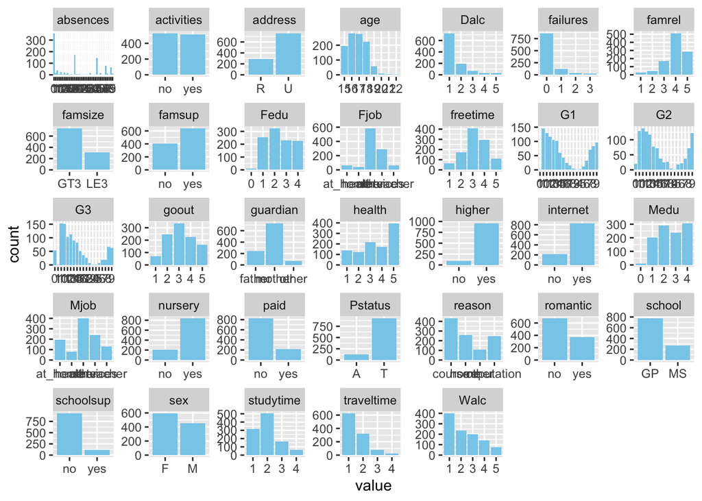

### Correlation

When considering the distribution of *traveltime*, *studytime*, *failures*, *famrel*, *freetime*, *goout*, *Dalc*, *Walc*, *health*, and *absences* across different G3 categories, it becomes evident that these variables show a relatively even distribution within each G3 group.

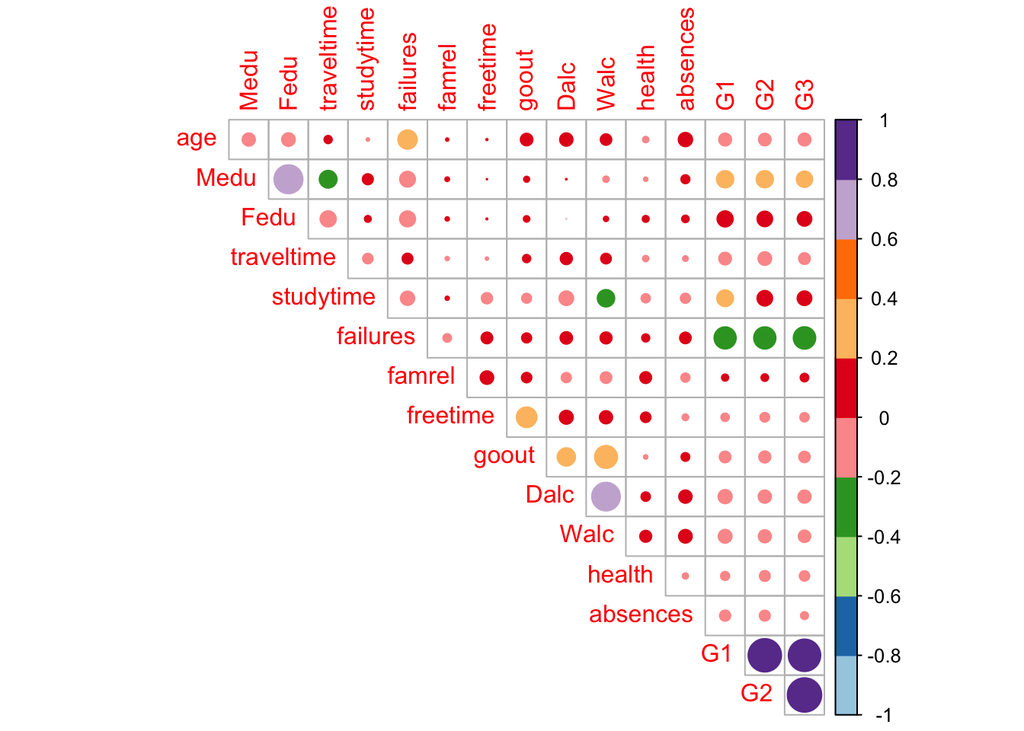

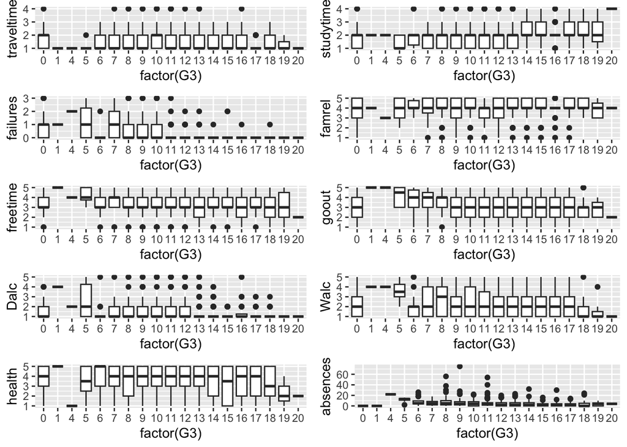

### Missing values

The dataset is complete with no missing values.

```
## [1] 0
```

```
## [1] 0
```

## Data Preparation

### Merging datasets

Includes:

- Merging datasets
- Renaming columns
- Adding new columns
- Replacing binary values
- Remove rows

Reset the index of **df_student** dataframe that combine above.

```
##             vars    n  mean   sd median trimmed  mad min max range  skew
## school*        1 1044  1.26 0.44      1    1.20 0.00   1   2     1  1.09
## sex*           2 1044  1.43 0.50      1    1.42 0.00   1   2     1  0.27
## age            3 1044 16.73 1.24     17   16.67 1.48  15  22     7  0.43
## address*       4 1044  1.73 0.45      2    1.78 0.00   1   2     1 -1.02
## famsize*       5 1044  1.29 0.46      1    1.24 0.00   1   2     1  0.91
## Pstatus*       6 1044  1.88 0.32      2    1.98 0.00   1   2     1 -2.40
## Medu           7 1044  2.60 1.12      3    2.64 1.48   0   4     4 -0.14
## Fedu           8 1044  2.39 1.10      2    2.37 1.48   0   4     4  0.12
## Mjob*          9 1044  3.03 1.24      3    3.03 1.48   1   5     4 -0.24
## Fjob*         10 1044  3.25 0.86      3    3.30 0.00   1   5     4 -0.47
## reason*       11 1044  2.17 1.20      2    2.08 1.48   1   4     3  0.50
## guardian*     12 1044  1.84 0.53      2    1.83 0.00   1   3     2 -0.16
## traveltime    13 1044  1.52 0.73      1    1.38 0.00   1   4     3  1.37
## studytime     14 1044  1.97 0.83      2    1.89 1.48   1   4     3  0.67
## failures      15 1044  0.26 0.66      0    0.09 0.00   0   3     3  2.78
## schoolsup*    16 1044  1.11 0.32      1    1.02 0.00   1   2     1  2.43
## famsup*       17 1044  1.61 0.49      2    1.64 0.00   1   2     1 -0.46
## paid*         18 1044  1.21 0.41      1    1.14 0.00   1   2     1  1.42
## activities*   19 1044  1.49 0.50      1    1.49 0.00   1   2     1  0.02
## nursery*      20 1044  1.80 0.40      2    1.87 0.00   1   2     1 -1.50
## higher*       21 1044  1.91 0.28      2    2.00 0.00   1   2     1 -2.97
## internet*     22 1044  1.79 0.41      2    1.86 0.00   1   2     1 -1.44
## romantic*     23 1044  1.36 0.48      1    1.32 0.00   1   2     1  0.60
## famrel        24 1044  3.94 0.93      4    4.05 1.48   1   5     4 -1.05
## freetime      25 1044  3.20 1.03      3    3.20 1.48   1   5     4 -0.18
## goout         26 1044  3.16 1.15      3    3.16 1.48   1   5     4  0.04
## Dalc          27 1044  1.49 0.91      1    1.28 0.00   1   5     4  2.15
## Walc          28 1044  2.28 1.29      2    2.14 1.48   1   5     4  0.62
## health        29 1044  3.54 1.42      4    3.68 1.48   1   5     4 -0.50
## absences      30 1044  4.43 6.21      2    3.27 2.97   0  75    75  3.73
## G1            31 1044 11.21 2.98     11   11.18 2.97   0  19    19  0.08
## G2            32 1044 11.25 3.29     11   11.32 2.97   0  19    19 -0.50
## G3            33 1044 11.34 3.86     11   11.66 2.97   0  20    20 -0.98
##             kurtosis   se
## school*        -0.81 0.01
## sex*           -1.93 0.02
## age             0.03 0.04
## address*       -0.97 0.01
## famsize*       -1.18 0.01
```

[output cut: 13 more lines]

```
## activities*    -2.00 0.02
## nursery*        0.24 0.01
## higher*         6.80 0.01
## internet*       0.07 0.01
## romantic*      -1.64 0.01
## famrel          1.27 0.03
## freetime       -0.37 0.03
## goout          -0.84 0.04
## Dalc            4.44 0.03
## Walc           -0.79 0.04
## health         -1.09 0.04
## absences       26.41 0.19
## G1             -0.34 0.09
## G2              1.32 0.10
## G3              1.72 0.12
```

### Adding new columns

Use the Mutate() method to create a new column named **G1G2avg** and **G1G2avg** for future analysis.

```
##   school sex age address famsize Pstatus Medu Fedu     Mjob     Fjob     reason
## 1     GP   F  18       U     GT3       A    4    4  at_home  teacher     course
## 2     GP   F  17       U     GT3       T    1    1  at_home    other     course
## 3     GP   F  15       U     LE3       T    1    1  at_home    other      other
## 4     GP   F  15       U     GT3       T    4    2   health services       home
## 5     GP   F  16       U     GT3       T    3    3    other    other       home
## 6     GP   M  16       U     LE3       T    4    3 services    other reputation
##   guardian traveltime studytime failures schoolsup famEdsup paid activities
## 1   mother          2         2        0       yes       no   no         no
## 2   father          1         2        0        no      yes   no         no
## 3   mother          1         2        3       yes       no  yes         no
## 4   mother          1         3        0        no      yes  yes        yes
## 5   father          1         2        0        no      yes  yes         no
## 6   mother          1         2        0        no      yes  yes        yes
##   nursery higher internet romantic famrel freetime friendtime Dalc weekAlc
## 1     yes    yes       no       no      4        3          4    1       1
## 2      no    yes      yes       no      5        3          3    1       1
## 3     yes    yes      yes       no      4        3          2    2       3
## 4     yes    yes      yes      yes      3        2          2    1       1
## 5     yes    yes       no       no      4        3          2    1       2
## 6     yes    yes      yes       no      5        4          2    1       2
##   health absences G1 G2 G3 G1G2avg
## 1      3        6  5  6  6     5.5
## 2      3        4  5  5  6     5.0
## 3      3       10  7  8 10     7.5
## 4      5        2 15 14 15    14.5
## 5      5        4  6 10 10     8.0
## 6      5       10 15 15 15    15.0
```

```
##   school sex age address famsize Pstatus Medu Fedu     Mjob     Fjob     reason
## 1     GP   F  18       U     GT3       A    4    4  at_home  teacher     course
## 2     GP   F  17       U     GT3       T    1    1  at_home    other     course
## 3     GP   F  15       U     LE3       T    1    1  at_home    other      other
## 4     GP   F  15       U     GT3       T    4    2   health services       home
## 5     GP   F  16       U     GT3       T    3    3    other    other       home
## 6     GP   M  16       U     LE3       T    4    3 services    other reputation
##   guardian traveltime studytime failures schoolsup famEdsup paid activities
## 1   mother          2         2        0       yes       no   no         no
## 2   father          1         2        0        no      yes   no         no
## 3   mother          1         2        3       yes       no  yes         no
## 4   mother          1         3        0        no      yes  yes        yes
## 5   father          1         2        0        no      yes  yes         no
## 6   mother          1         2        0        no      yes  yes        yes
##   nursery higher internet romantic famrel freetime friendtime Dalc weekAlc
## 1     yes    yes       no       no      4        3          4    1       1
## 2      no    yes      yes       no      5        3          3    1       1
## 3     yes    yes      yes       no      4        3          2    2       3
## 4     yes    yes      yes      yes      3        2          2    1       1
## 5     yes    yes       no       no      4        3          2    1       2
## 6     yes    yes      yes       no      5        4          2    1       2
##   health absences G1 G2 G3 G1G2avg G1G2G3avg
## 1      3        6  5  6  6     5.5       5.7
## 2      3        4  5  5  6     5.0       5.3
## 3      3       10  7  8 10     7.5       8.3
## 4      5        2 15 14 15    14.5      14.7
## 5      5        4  6 10 10     8.0       8.7
## 6      5       10 15 15 15    15.0      15.0
```

```
## [1] 11.26686
```

### Replacing binary values

Changing binary values (yes and no) to 1 and 0 can be beneficial in data analysis because it allows for easier computation and comparison of values. For example, it allows me to perform mathematical operations and comparisons more easily. It also enables the use of machine learning algorithms that require numerical input.

```
## 'data.frame':    1044 obs. of  36 variables:
##  $ school    : chr  "GP" "GP" "GP" "GP" ...
##  $ sex       : chr  "F" "F" "F" "F" ...
##  $ age       : int  18 17 15 15 16 16 16 17 15 15 ...
##  $ address   : chr  "U" "U" "U" "U" ...
##  $ famsize   : chr  "GT3" "GT3" "LE3" "GT3" ...
##  $ Pstatus   : chr  "A" "T" "T" "T" ...
##  $ Medu      : int  4 1 1 4 3 4 2 4 3 3 ...
##  $ Fedu      : int  4 1 1 2 3 3 2 4 2 4 ...
##  $ Mjob      : chr  "at_home" "at_home" "at_home" "health" ...
##  $ Fjob      : chr  "teacher" "other" "other" "services" ...
##  $ reason    : chr  "course" "course" "other" "home" ...
##  $ guardian  : chr  "mother" "father" "mother" "mother" ...
##  $ traveltime: num  2 1 1 1 1 1 1 2 1 1 ...
##  $ studytime : num  2 2 2 3 2 2 2 2 2 2 ...
```

[output cut: 22 more lines]

[output not shown]

### Remove rows

Any record that has a value of 0 for any of the three exams may indicate that the test was not taken or abandoned, and such records will be removed from the dataset to avoid interference with the analysis

## Data Visualization

### Romantic status

In general, students who are in a romantic relationship may have a more challenging time focusing on their studies compared to those who are not. It is crucial to examine whether this is indeed the case.

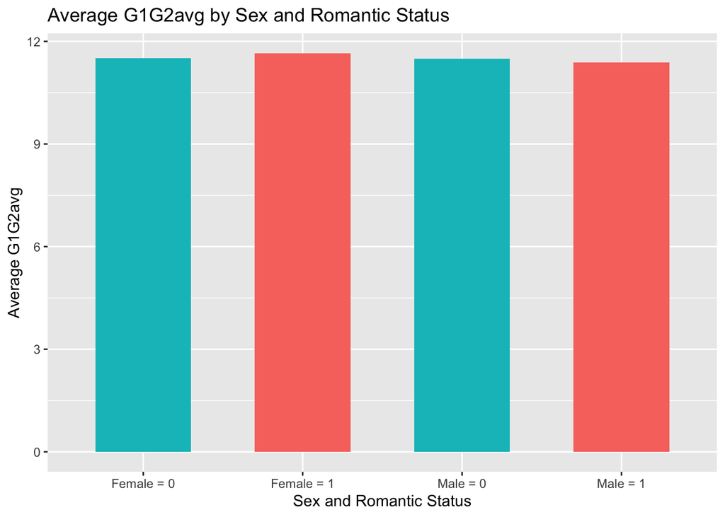

### Study Time

The findings suggest that students who study for a longer duration have a higher average score compared to those who study for a shorter duration.

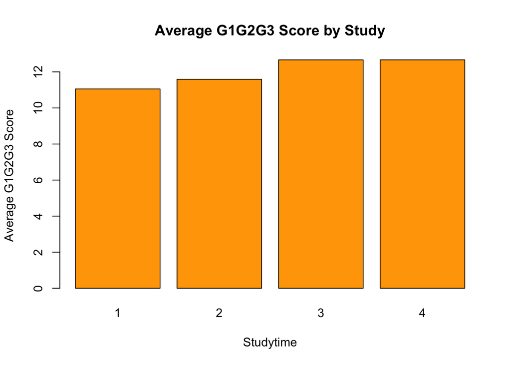

### Internet

The accessibility of the internet has become increasingly important in modern education, as it provides students with access to a vast array of learning materials that might otherwise be unavailable. It is widely recognized that the internet has the potential to enhance students’ educational experiences, but it is important to assess whether this potential is being fully realized. Therefore, it is necessary to examine whether the same positive results regarding internet accessibility and academic performance were obtained in the experiment.

The following graph indicates that the difference in academic performance between students with and without Internet access is negligible.

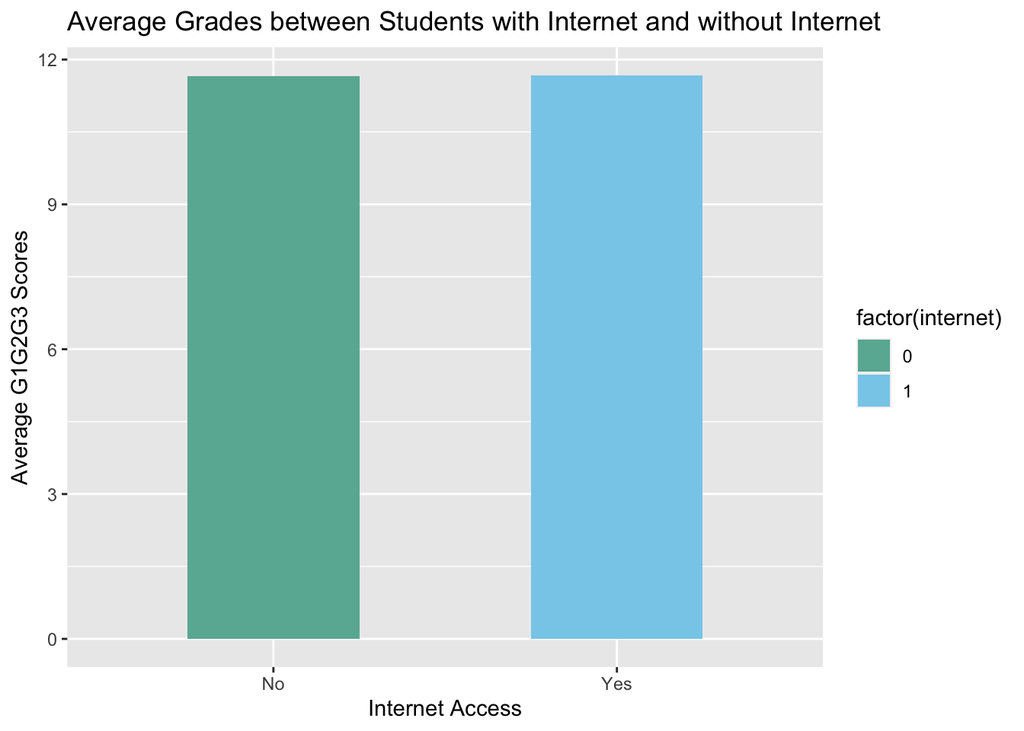

## Models

### Model 1

**Multiple Linear Regrssion**

```
##
## Call:
## lm(formula = G3 ~ traveltime + studytime + failures + schoolsup +
##     famEdsup + paid + activities + nursery + higher + internet +
##     romantic + famrel + freetime + friendtime + Dalc + weekAlc +
##     health + absences, data = df_student)
##
## Residuals:
##     Min      1Q  Median      3Q     Max
## -9.2177 -1.7758 -0.1385  1.7651  8.9043
##
## Coefficients: (7 not defined because of singularities)
##             Estimate Std. Error t value Pr(>|t|)
## (Intercept) 13.26085    0.59033  22.464  < 2e-16 ***
## traveltime  -0.22328    0.11627  -1.920  0.05510 .
## studytime    0.37966    0.10438   3.637  0.00029 ***
## failures    -1.35423    0.14055  -9.635  < 2e-16 ***
## schoolsup    0.01056    0.16819   0.063  0.94994
## famEdsup          NA         NA      NA       NA
## paid              NA         NA      NA       NA
## activities        NA         NA      NA       NA
## nursery           NA         NA      NA       NA
## higher            NA         NA      NA       NA
## internet          NA         NA      NA       NA
## romantic          NA         NA      NA       NA
## famrel       0.13527    0.09310   1.453  0.14654
## freetime    -0.03479    0.08703  -0.400  0.68941
## friendtime  -0.17674    0.08490  -2.082  0.03761 *
## Dalc        -0.16142    0.11881  -1.359  0.17458
## weekAlc     -0.07156    0.09104  -0.786  0.43206
## health      -0.15528    0.05990  -2.592  0.00968 **
## absences    -0.06963    0.01368  -5.089 4.31e-07 ***
## ---
## Signif. codes:  0 '***' 0.001 '**' 0.01 '*' 0.05 '.' 0.1 ' ' 1
##
## Residual standard error: 2.63 on 978 degrees of freedom
## Multiple R-squared:  0.1941, Adjusted R-squared:  0.185
## F-statistic: 21.41 on 11 and 978 DF,  p-value: < 2.2e-16
```

[output not shown]

[output cut: 707 more lines]

```
## + freetime:Dalc          1     0.821 6538.7 1910.9
## + freetime:health        1     0.624 6538.9 1910.9
## + traveltime:absences    1     0.346 6539.1 1911.0
## + schoolsup:freetime     1     0.227 6539.3 1911.0
## + friendtime:absences    1     0.159 6539.3 1911.0
## + health:absences        1     0.068 6539.4 1911.0
## + traveltime:schoolsup   1     0.019 6539.5 1911.0
## + traveltime:freetime    1     0.004 6539.5 1911.0
## + studytime:weekAlc      1     0.003 6539.5 1911.0
## + Dalc:health            1     0.000 6539.5 1911.0
## - weekAlc:absences       1    35.688 6575.2 1912.4
## - schoolsup:weekAlc      1    36.279 6575.8 1912.5
## - traveltime:failures    1    38.320 6577.8 1912.8
## - failures:absences      1    47.261 6586.8 1914.2
## - freetime:absences      1    56.775 6596.3 1915.6
```

```
##
## Call:
## lm(formula = G3 ~ traveltime + studytime + failures + schoolsup +
##     freetime + friendtime + Dalc + weekAlc + health + absences +
##     schoolsup:weekAlc + freetime:absences + weekAlc:absences +
##     freetime:friendtime + failures:absences + traveltime:failures +
##     traveltime:Dalc + studytime:friendtime + failures:health,
##     data = df_student)
##
## Residuals:
##     Min      1Q  Median      3Q     Max
## -8.4950 -1.7135 -0.0963  1.7400  7.5423
##
## Coefficients:
##                      Estimate Std. Error t value Pr(>|t|)
## (Intercept)          11.67583    1.09895  10.625  < 2e-16 ***
## traveltime           -0.55544    0.21148  -2.627  0.00876 **
## studytime             0.80154    0.28664   2.796  0.00527 **
## failures             -2.98989    0.56658  -5.277 1.62e-07 ***
## schoolsup             0.71758    0.33909   2.116  0.03458 *
## freetime              0.56689    0.22533   2.516  0.01203 *
## friendtime            0.49541    0.29945   1.654  0.09837 .
## Dalc                 -0.44404    0.20653  -2.150  0.03180 *
## weekAlc              -0.05225    0.12122  -0.431  0.66654
## health               -0.16349    0.06233  -2.623  0.00885 **
## absences             -0.04431    0.03710  -1.194  0.23264
## schoolsup:weekAlc    -0.29971    0.12920  -2.320  0.02056 *
## freetime:absences    -0.03482    0.01200  -2.902  0.00379 **
## weekAlc:absences      0.02564    0.01114   2.301  0.02162 *
## freetime:friendtime  -0.12612    0.06629  -1.903  0.05738 .
## failures:absences     0.06394    0.02415   2.648  0.00824 **
## traveltime:failures   0.40066    0.16805   2.384  0.01731 *
## traveltime:Dalc       0.15748    0.09850   1.599  0.11018
## studytime:friendtime -0.13565    0.08693  -1.560  0.11897
## failures:health       0.14630    0.10073   1.452  0.14673
## ---
## Signif. codes:  0 '***' 0.001 '**' 0.01 '*' 0.05 '.' 0.1 ' ' 1
##
## Residual standard error: 2.596 on 970 degrees of freedom
## Multiple R-squared:  0.2211, Adjusted R-squared:  0.2058
## F-statistic: 14.49 on 19 and 970 DF,  p-value: < 2.2e-16
```

```
## [1] 2.551927
```

```
## [1] 2.473734
```

### Model 2

**Random Forest Model**

```
##
## Call:
##  randomForest(formula = G3 ~ traveltime + studytime + failures +      schoolsup + famEdsup + paid + activities + nursery + higher +      internet + romantic + famrel + freetime + friendtime + Dalc +      weekAlc + health + absences, data = df_student)
##                Type of random forest: regression
##                      Number of trees: 500
## No. of variables tried at each split: 6
##
##           Mean of squared residuals: 6.811214
##                     % Var explained: 19.68
```

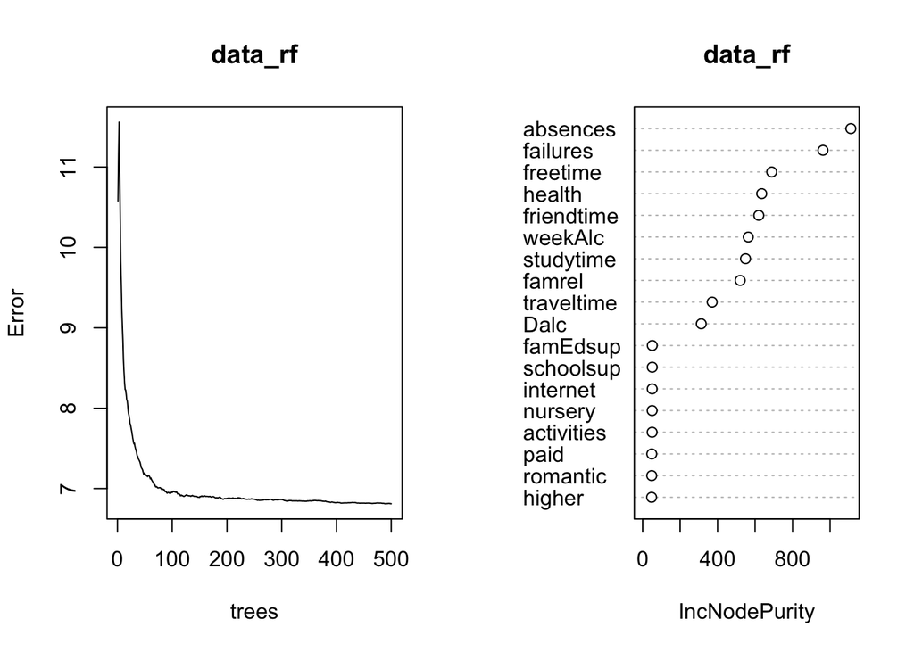

```
## [1] 1.43365
```

### Model 3

**decission tree model**

```
## n= 990
##
## node), split, n, deviance, yval
##       * denotes terminal node
##
##  1) root 990 8395.4750 11.949490
##    2) failures>=0.5 154  778.4935  9.493506 *
##    3) failures< 0.5 836 6516.9570 12.401910
##      6) absences>=3.5 378 3081.1560 11.875660
##       12) studytime< 2.5 295 2324.5900 11.562710 *
##       13) studytime>=2.5 83  624.9880 12.987950 *
##      7) absences< 3.5 458 3244.7180 12.836240
##       14) studytime< 1.5 111  681.8559 12.036040 *
##       15) studytime>=1.5 347 2469.0490 13.092220 *
```

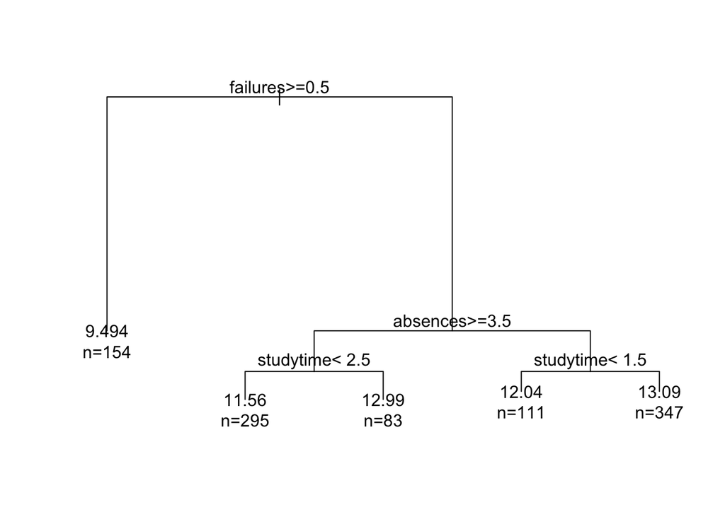

```
## [1] 2.574329
```

## Model Selection

Why is regression model verification necessary? Inaccurate statistical models can be created if the data are irregular or if the relationship between the predictor and response variables is incorrectly established. In other words, a statistical model is created by concluding that there is no relationship between the predictor and the response variable even though there is actually a relationship, or that there is a relationship between the predictor and the response variable despite no relationship, but the actual real applying the model to the world can lead to mispredictions, making unnecessary and serious errors.

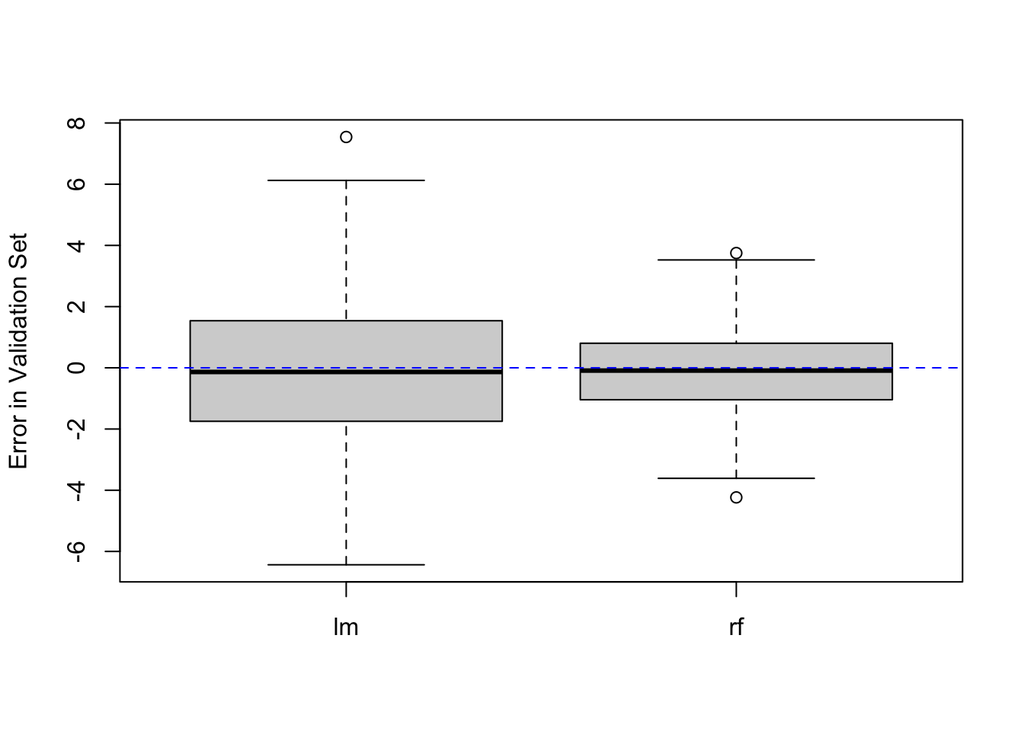

## Conclusion

In retrospect, I believe that the study would have been more robust if the data had been more precise and detailed. Investigating the underlying conditions that motivate students to study harder and how these factors affect their academic performance would have provided a more precise understanding of the relationship between external factors and academic success. While the survey data I used did provide useful insights, a more focused approach that delves into the specific motivators for studying and how these are related to academic outcomes could have yielded more comprehensive and sophisticated results.

Given more time, I would like to collect more extensive binary data and analyze it using binary regression models. This would allow me to examine the relationship between specific factors and academic performance in greater detail and to identify the factors that are most closely associated with academic success. By using more advanced statistical techniques, I could also explore the interplay between different external factors and their combined effects on academic performance. Such an analysis would be useful in designing targeted interventions to support students in their academic pursuits and improve educational outcomes.

Overall, this study provides a starting point for future research in the field of education and highlights the need for more comprehensive and detailed data to fully understand the complex relationship between external factors and academic success.

## References

Data source: P. Cortez and A. Silva. Using Data Mining to Predict Secondary School Student Performance. In A. Brito and J. Teixeira Eds., Proceedings of 5th FUture BUsiness TEChnology Conference (FUBUTEC 2008) pp. 5-12, Porto, Portugal, April, 2008, EUROSIS, ISBN 978-9077381-39-7. Accessed via [Kaggle](https://www.kaggle.com/datasets/uciml/student-alcohol-consumption)

## Appendix 1: Data Dictionary

(from [Kaggle](https://www.kaggle.com/datasets/uciml/student-alcohol-consumption))

- *school* - student’s school (binary: ‘GP’ - Gabriel Pereira or ‘MS’ - Mousinho da Silveira)
- *sex* - student’s sex (binary: ‘F’ - female or ‘M’ - male)
- *age* - student’s age (numeric: from 15 to 22)
- *address* - student’s home address type (binary: ‘U’ - urban or ‘R’ - rural)
- *famsize* - family size (binary: ‘LE3’ - less or equal to 3 or ‘GT3’ - greater than 3)
- *Pstatus* - parent’s cohabitation status (binary: ‘T’ - living together or ‘A’ - apart)
- - *Medu* - mother’s education (numeric: 0 - none, 1 - primary education (4th grade), 2 – 5th to 9th grade, 3 – secondary education or 4 – * *higher* education)
- *Fedu* - father’s education (numeric: 0 - none, 1 - primary education (4th grade), 2 – 5th to 9th grade, 3 – secondary education or 4 – higher education)
- *Mjob* - mother’s job (nominal: ‘teacher’, ‘health’ care related, civil ‘services’ (e.g. administrative or police), ‘at_home’ or ‘other’)
- *Fjob* - father’s job (nominal: ‘teacher’, ‘health’ care related, civil ‘services’ (e.g. administrative or police), ‘at_home’ or ‘other’)
- *reason* - reason to choose this school (nominal: close to ‘home’, school ‘reputation’, ‘course’ preference or ‘other’)
- *guardian* - student’s guardian (nominal: ‘mother’, ‘father’ or ‘other’)
- *traveltime* - home to school travel time (numeric: 1 - <15 min., 2 - 15 to 30 min., 3 - 30 min. to 1 hour, or 4 - >1 hour)
- *studytime* - weekly study time (numeric: 1 - <2 hours, 2 - 2 to 5 hours, 3 - 5 to 10 hours, or 4 - >10 hours)
- *failures* - number of past class failures (numeric: n if 1<=n<3, else 4)
- *schoolsup* - extra educational support (binary: yes or no)
- *famsup* - family educational support (binary: yes or no)
- *paid* - extra paid classes within the course subject (Math or Portuguese) (binary: yes or no)
- *activities* - extra-curricular activities (binary: yes or no)
- *nursery* - attended nursery school (binary: yes or no)
- *higher* - wants to take higher education (binary: yes or no)
- *internet* - Internet access at home (binary: yes or no)
- *romantic* - with a romantic relationship (binary: yes or no)
- *famrel* - quality of family relationships (numeric: from 1 - very bad to 5 - excellent)
- *freetime* - free time after school (numeric: from 1 - very low to 5 - very high)
- *goout* - going out with friends (numeric: from 1 - very low to 5 - very high)
- *Dalc* - workday alcohol consumption (numeric: from 1 - very low to 5 - very high)
- *Walc* - weekend alcohol consumption (numeric: from 1 - very low to 5 - very high)
- *health* - current health status (numeric: from 1 - very bad to 5 - very good)
- *absences* - number of school absences (numeric: from 0 to 93)

These grades are related with the course subject, Math or Portuguese:

*G1* - first period grade (numeric: from 0 to 20) *G2* - second period grade (numeric: from 0 to 20) *G3* - final grade (numeric: from 0 to 20, output target)